# N2138_9 exp

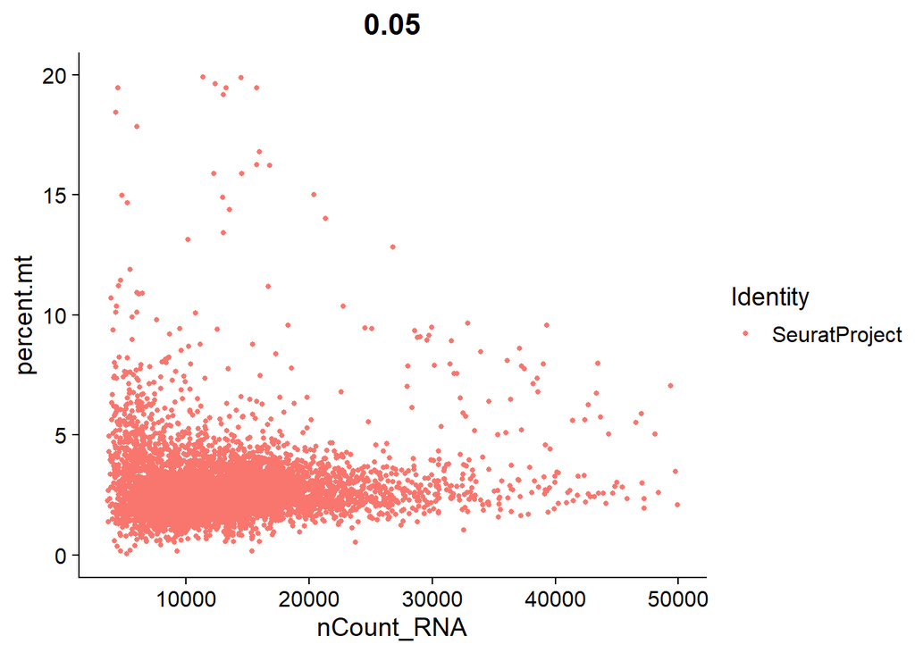

```r
FeatureScatter(N2234_1, feature1 = "nCount_RNA", feature2 = "percent.mt")
```

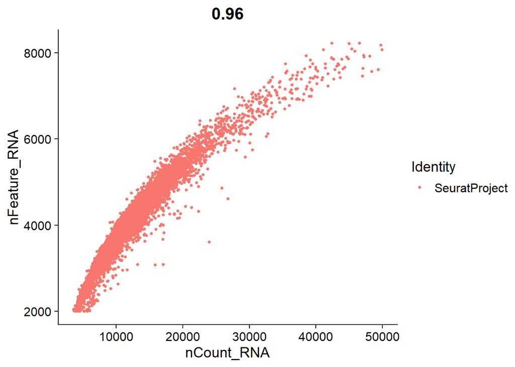

```r
FeatureScatter(N2234_1, feature1 = "nCount_RNA", feature2 = "nFeature_RNA")
```

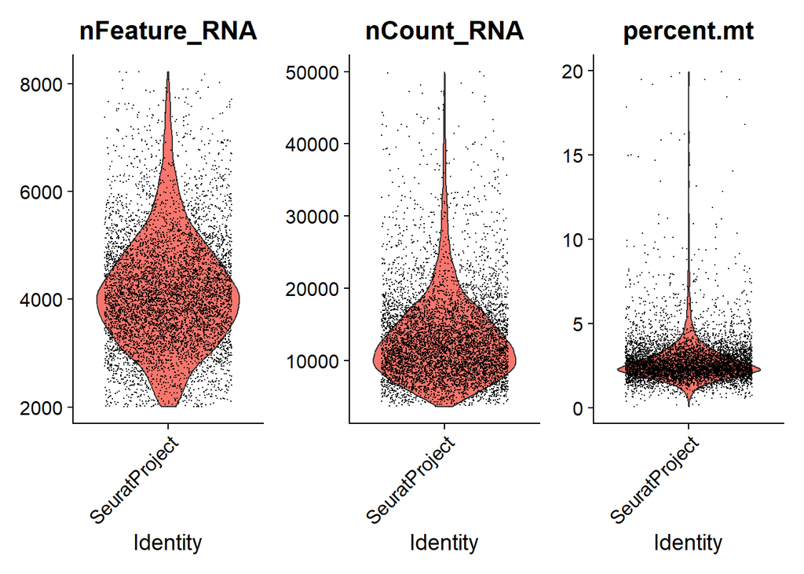

```r
VlnPlot(N2234_1, features = c("nFeature_RNA", "nCount_RNA", "percent.mt"), ncol = 3)
```

Lets go even lower to 10% percent.mt (also based on integrated datasets). To have the wildtype datasets as clean as possible.

```r
N2234_1 <- subset(N2234_1, subset = nCount_RNA <50000 & nFeature_RNA > 2000 &percent.mt <10)
```

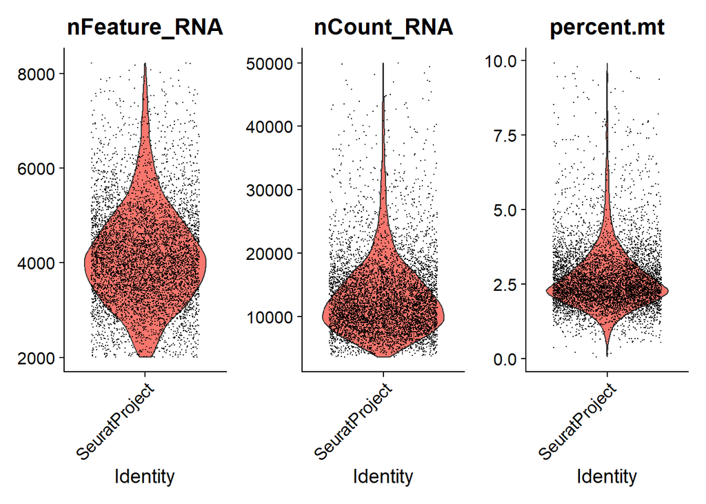

```r
VlnPlot(N2234_1, features = c("nFeature_RNA", "nCount_RNA", "percent.mt"), ncol = 3)
```

Lets normalise the data using SCTransform V2, with regression of percent.mt

```r
N2234_1<- SCTransform(N2234_1, vst.flavor = "v2", vars.to.regress = "percent.mt")
```

```
## vst.flavor='v2' set, setting model to use fixed slope and exclude poisson genes.
```

```
## Calculating cell attributes from input UMI matrix: log_umi
```

```
## Total Step 1 genes: 21361
```

```
## Total overdispersed genes: 19006
```

```
## Excluding 2355 genes from Step 1 because they are not overdispersed.
```

```
## Variance stabilizing transformation of count matrix of size 21836 by 6411
```

```
## Model formula is y ~ log_umi
```

```
## Get Negative Binomial regression parameters per gene
```

```
## Using 2000 genes, 5000 cells
```

```
## Setting estimate of  70 genes to inf as theta_mm/theta_mle < 1e-3
```

```
## # of step1 poisson genes (variance < mean): 0
```

```
## # of low mean genes (mean < 0.001): 587
```

[output not shown]

```
## Total # of poisson genes (theta=Inf; variance < mean): 2767
```

```
## Calling offset model for all 2767 poisson genes
```

```
## Found 99 outliers - those will be ignored in fitting/regularization step
```

```
## Ignoring theta inf genes
```

```
## Replacing fit params for 2767 poisson genes by theta=Inf
```

```
## Setting min_variance based on median UMI:  0.04
```

```
## Second step: Get residuals using fitted parameters for 21836 genes
```

```
## Computing corrected count matrix for 21836 genes
```

```
## Wall clock passed: Time difference of 1.269726 mins
```

```
## Determine variable features
```

```
## Place corrected count matrix in counts slot
```

```
## Centering data matrix
```

```
## Set default assay to SCT
```

```r
N2234_1 <- RunPCA(N2234_1, verbose = FALSE)
```

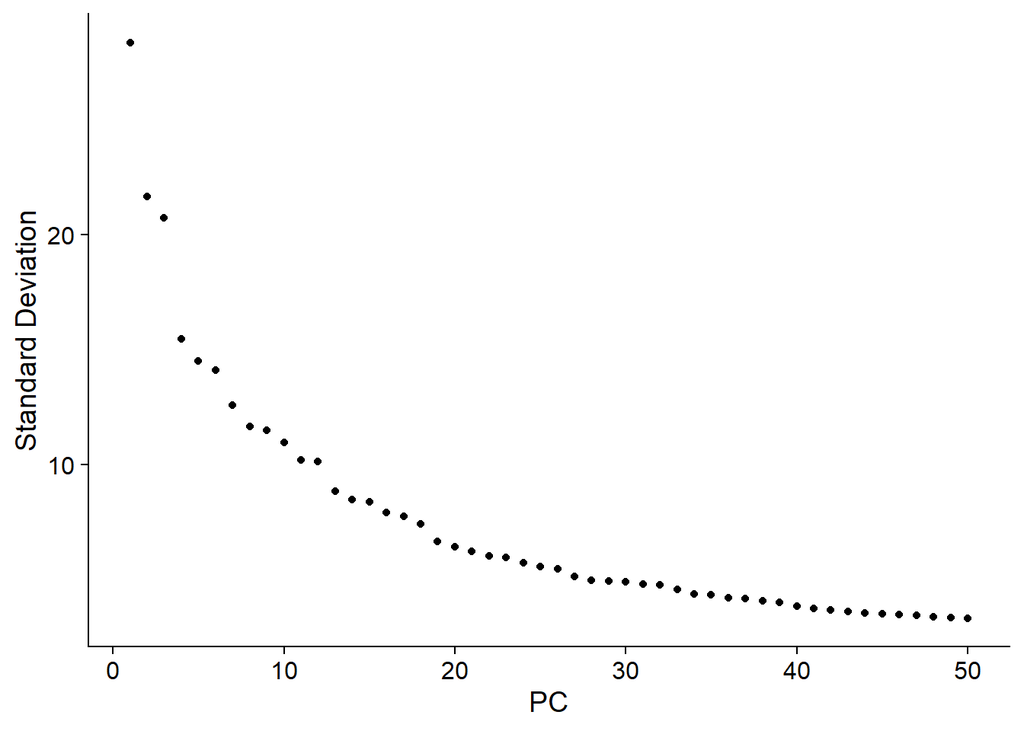

```r
ElbowPlot(N2234_1, ndims = 50)
```

Before I overclustered the datasets a bit, but for this initial filtering I am only interested in getting out the Epcam+ clusters, so I am not clustering at max settings, but at 30 for now

```r
N2234_1 <- FindNeighbors(N2234_1, dims = 1:30, verbose = FALSE)
N2234_1 <- FindClusters(N2234_1, verbose = FALSE)
N2234_1 <- RunUMAP(N2234_1, dims = 1:30, verbose = FALSE)
```

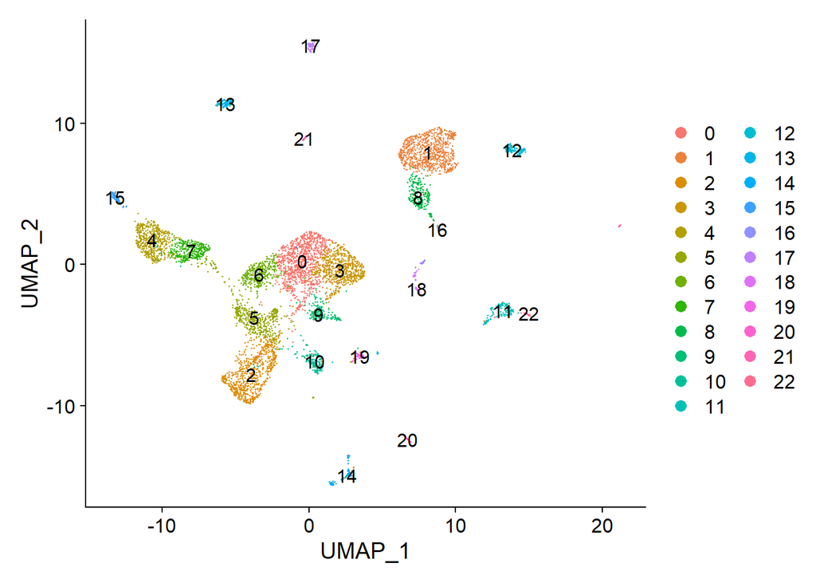

```r
DimPlot(N2234_1, label = TRUE)
```

```r
OCmarkers <- c("Epcam", "Sox2", "Myo7a", "Myo6", "Ccer2", "Otof", "Fgf8", "Ocm", "Pou4f3", "Fabp7", "S100a1", "Hey2", "Npy", "Mansc4", "Oc90")
```

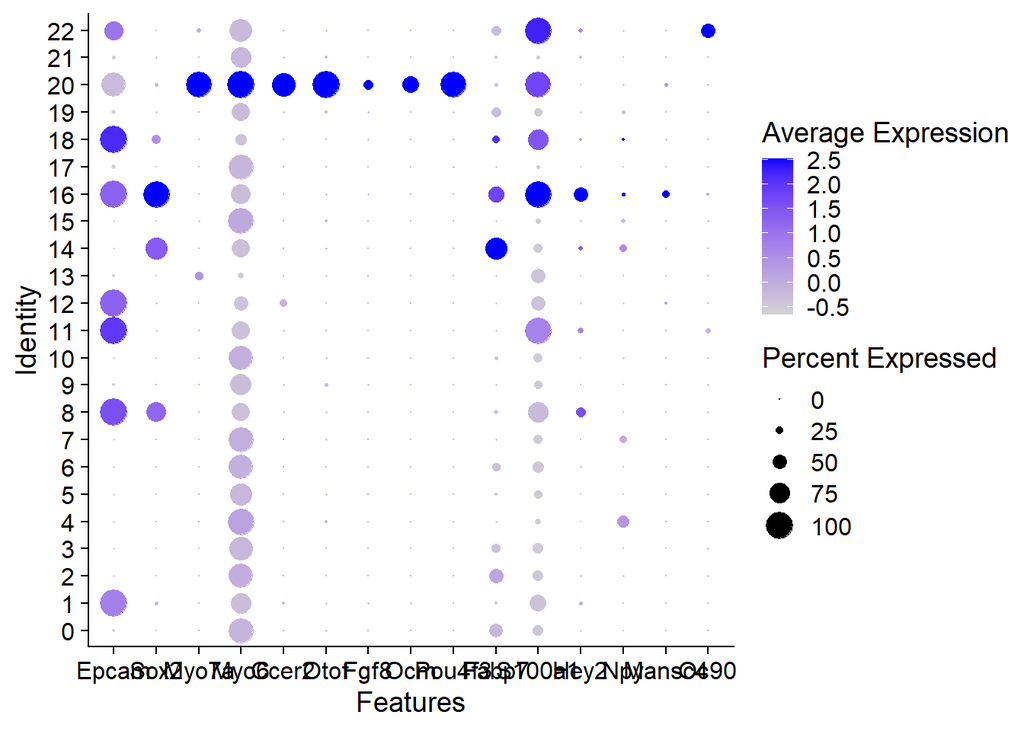

```r
DotPlot(N2234_1, features = OCmarkers)
```

```r
DefaultAssay(N2234_1) <- "SCT"
```

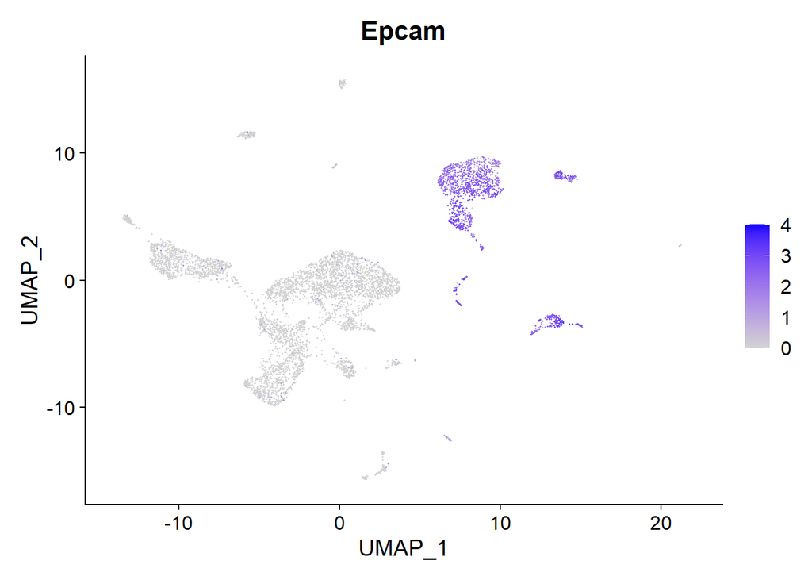

```r
FeaturePlot(N2234_1, features = c("Epcam"))
```

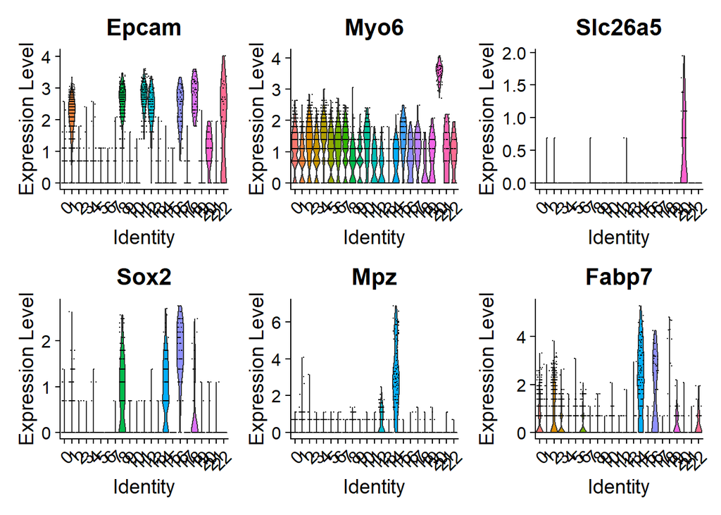

```r
VlnPlot(N2234_1, features = c("Epcam", "Myo6", "Slc26a5", "Sox2", "Mpz", "Fabp7"))
```

Clusters of interest are, Epcam and Myo6 (Sox2+, Epcam- clusters are glia, not including glia right now) : 1, 8, 11, 12, 16, 18, 20, 22,

But first I will remove the doublets.

```r
sce <- as.SingleCellExperiment(N2234_1)
sce <- scDblFinder(sce)
```

```
## Creating ~5129 artificial doublets...
```

```
## Dimensional reduction
```

```
## Evaluating kNN...
```

```
## Training model...
```

```
## iter=0, 517 cells excluded from training.
```

```
## iter=1, 445 cells excluded from training.
```

```
## iter=2, 439 cells excluded from training.
```

```
## Threshold found:0.429
```

```
## 334 (5.2%) doublets called
```

```r
sce_seurat <- as.Seurat(sce)
```

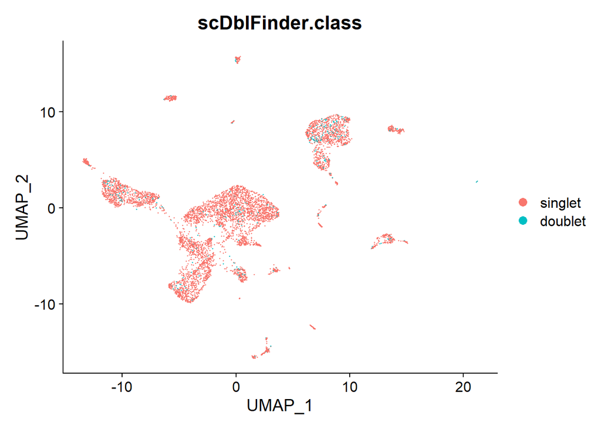

```r
DimPlot(sce_seurat, group.by = "scDblFinder.class")
```

```r
Idents(sce_seurat) <- "scDblFinder.class"
```

```r
N2234_1 <- subset(sce_seurat, scDblFinder.class == "singlet")
```

Lets subset to Epcam+ clusters as indicated above

```r
Idents(N2234_1) <- "seurat_clusters"
```

```r
N2234_1_QC <- subset(N2234_1, idents= c("1", "8", "11", "12", "16", "18", "20", "22"))
```

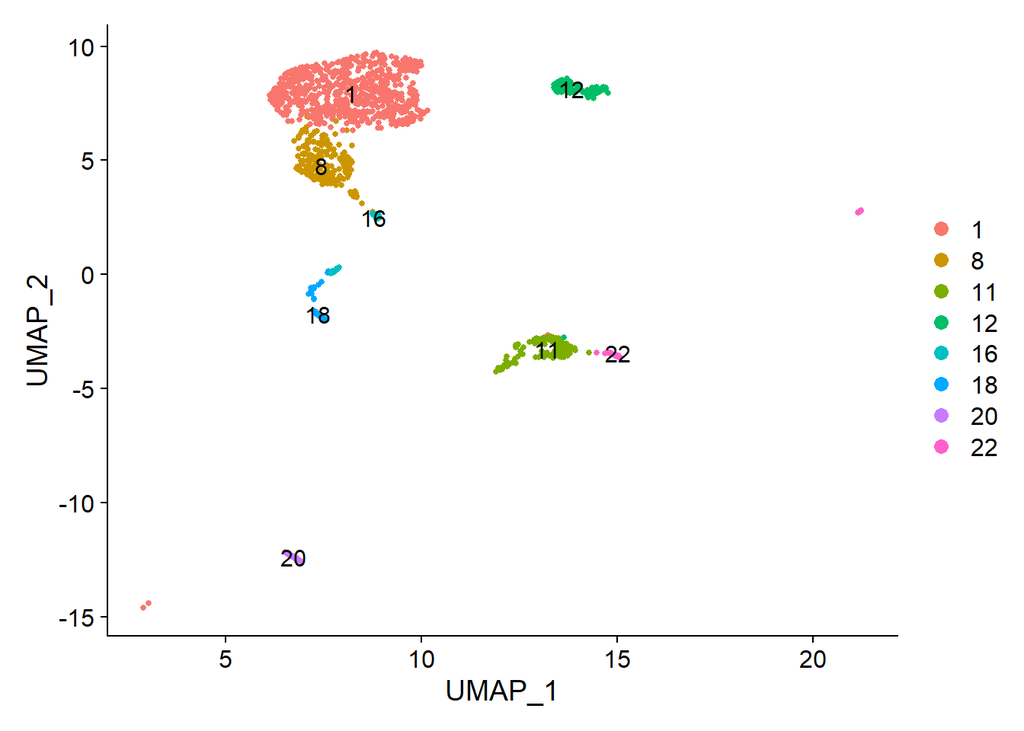

```r
DimPlot(N2234_1_QC, label = TRUE)
```

```r
N2234_1_QC
```

```
## An object of class Seurat
## 54122 features across 1400 samples within 2 assays
## Active assay: RNA (32286 features, 0 variable features)
##  1 other assay present: SCT
##  2 dimensional reductions calculated: PCA, UMAP
```

I am removing the dimensional reductions previously calculated, because it cannot overwrite and will name it umap instead of UMAP, but the default used for visualisation will be UMAP unless other specified. Maybe this causes issues later also during integration?

```r
N2234_1_QC[["PCA"]] <- NULL
N2234_1_QC[["UMAP"]] <- NULL
```

```r
N2234_1_QC
```

```
## An object of class Seurat
## 54122 features across 1400 samples within 2 assays
## Active assay: RNA (32286 features, 0 variable features)
##  1 other assay present: SCT
```

```r
N2234_1_QC <- SCTransform(N2234_1_QC, vst.flavor = "v2", vars.to.regress = "percent.mt")
```

```
## vst.flavor='v2' set, setting model to use fixed slope and exclude poisson genes.
```

```
## Calculating cell attributes from input UMI matrix: log_umi
```

```
## Total Step 1 genes: 18353
```

```
## Total overdispersed genes: 15985
```

```
## Excluding 2368 genes from Step 1 because they are not overdispersed.
```

```
## Variance stabilizing transformation of count matrix of size 18353 by 1400
```

```
## Model formula is y ~ log_umi
```

```
## Get Negative Binomial regression parameters per gene
```

```
## Using 2000 genes, 1400 cells
```

```
## Setting estimate of  27 genes to inf as theta_mm/theta_mle < 1e-3
```

```
## # of step1 poisson genes (variance < mean): 0
```

```
## # of low mean genes (mean < 0.001): 0
```

```
## Total # of Step1 poisson genes (theta=Inf; variance < mean): 27
```

```
## Total # of poisson genes (theta=Inf; variance < mean): 2368
```

```
## Calling offset model for all 2368 poisson genes
```

```
## Found 55 outliers - those will be ignored in fitting/regularization step
```

```
## Ignoring theta inf genes
```

```
## Replacing fit params for 2368 poisson genes by theta=Inf
```

```
## Setting min_variance based on median UMI:  0.04
```

```
## Second step: Get residuals using fitted parameters for 18353 genes
```

```
## Computing corrected count matrix for 18353 genes
```

```
## Wall clock passed: Time difference of 16.60529 secs
```

```
## Determine variable features
```

```
## Place corrected count matrix in counts slot
```

```
## Centering data matrix
```

```
## Set default assay to SCT
```

```r
N2234_1_QC <- RunPCA(N2234_1_QC)
```

```
## PC_ 1
## Positive:  Nrxn3, Ctnnd2, Dlg2, Rbm24, Nrcam, Rims2, Kcnh8, Adgrv1, Ripor2, Frmd4b
##     Fry, Frmpd4, Tenm4, Sorbs1, Sema5b, Tnc, Zmat4, Usp46, Tmem178b, Dgkh
##     Smpx, Dock9, Ptprz1, Myo6, Raver2, Cacnb2, Thsd7b, Runx1t1, Pak3, Cep85l
## Negative:  Epyc, Rbms3, Cnmd, Fxyd6, Lgals1, Lmx1a, Dbi, Igf1, Vim, Lum
##     Nkain2, Pgm5, Scg2, Dclk1, Rasgef1b, Cdo1, Itm2b, Nupr1, Tshz2, Adgra3
##     Prss23, Mia, Ptgds, Irx3, Gas2, Aldh1a1, Rbpms, Sgk1, Slc26a4, Apoe
## PC_ 2
## Positive:  Prkg1, Rbms3, Nkain2, Pgm5, Adgrl3, Prss23, Fxyd6, Rasgef1b, Tshz2, Lgr5
##     Gas2, Negr1, Lmx1a, Ror1, Nupr1, Socs2, Vim, Fut9, Dbi, Stard13
##     Itgbl1, Scg2, Dclk1, Adgra3, Adamtsl1, Zbtb20, Apoe, Car12, Tanc2, Aldh1a1
## Negative:  Clu, Sgcz, Slc12a2, Robo2, Cdh4, Mia, Ecrg4, Itga8, Zfp804b, Slit2
##     Syt1, Calb1, Thrb, Galntl6, Agbl1, Pcolce2, Fras1, Tnfrsf19, Tectb, Stmn2
##     Sparcl1, Hunk, Adgrg2, Ldb2, Tmem117, Crabp1, Tecta, Podn, Eya1, Epyc
## PC_ 3
## Positive:  Tectb, Nckap5, Cpa6, Fbn2, Gpc6, Lsamp, Tecta, Sox2, Rorb, Jag1
##     Sorbs2, Hs6st2, Cyp26b1, Igfbp3, Dock5, Slitrk6, Rgs6, Fat3, Adgrg6, Mast4
##     Ntm, Tenm4, Ano1, Otogl, Gm14066, Ppp2r2b, Ptprk, Dgkb, Cdkn1b, Ebf1
## Negative:  Epyc, Calb1, Negr1, Nebl, Calml4, Slit3, Galnt7, Tpm1, Cdkn1c, Naaladl2
##     Dpp10, Rnf150, Cacna1d, Fxyd6, Calm2, Arhgap24, Rprm, Ablim1, Ptprq, Cnmd
##     Casz1, Cadm2, Lum, Gm30191, Pla2g7, Mob3b, Plxdc2, Srgap1, Olfm1, Nrp2
## PC_ 4
## Positive:  Sgcz, Trpm3, Fras1, Nrxn3, Sgcd, Nebl, Auts2, Thrb, Slc24a3, Rora
##     Sdk1, 2610307P16Rik, Slit2, Esrrg, Eya1, Rabgap1l, Tmem117, Mcc, Epyc, Pdzd2
##     Tex14, Slc12a2, Wnk1, Zbtb20, Tmeff2, Mir99ahg, B3gntl1, Cdh4, Zfp804b, Lrrtm4
## Negative:  Ecrg4, Mia, Tectb, Pdia6, Tm4sf1, Cpxm2, Tpt1, Eef1a1, Ptn, Rps8
##     Rps20, Rpl41, Rplp1, Rpl23, Manf, Ckb, Pdia3, Hsp90b1, Rpl13, Rps24
##     Rps12, Rps26, Clu, Tecta, Tmsb4x, Fkbp9, Tsen15, Nme2, Penk, Hspa5
## PC_ 5
## Positive:  Otoa, Cadm2, Slit3, Nfib, Cntn1, Ecrg4, Mid1, Adamtsl1, Gm29266, Rspo2
##     Tmem132c, Cdkn1c, Ablim1, Adamts9, Tm4sf1, Car9, Matn1, Pdgfc, Tns3, Tgfb2
##     Man1c1, Meg3, Fxyd3, Col27a1, Erbb4, Nkain2, Krt19, Ucma, Pcdh9, Kirrel3
## Negative:  Lgals1, Lum, Dclk1, Scg2, Nupr1, Vim, Lmx1a, Adgra3, Car12, Clu
##     Tanc2, Itga9, Lgr5, Fgf9, Itgbl1, Map1b, Col1a2, Mme, S100b, Chchd10
##     Ror1, Rasgef1b, Gas2, Otol1, Slc26a4, Ltbp1, Aqp5, Fut9, Sgk1, Col9a1
```

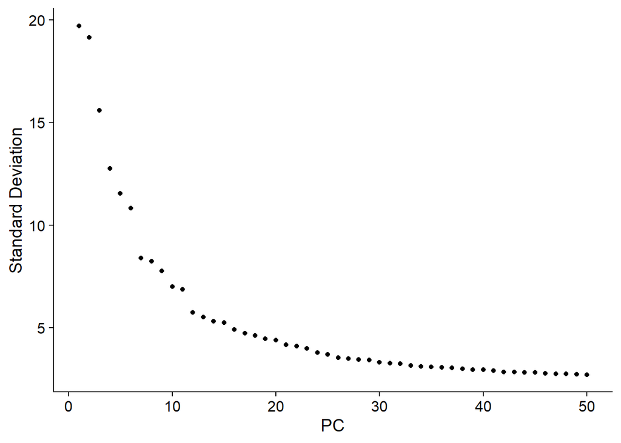

```r
ElbowPlot(N2234_1_QC, ndims = 50)
```

```r
N2234_1_QC <- FindNeighbors(N2234_1_QC, dims = 1:30)
N2234_1_QC <- FindClusters(N2234_1_QC)
```

```
## Modularity Optimizer version 1.3.0 by Ludo Waltman and Nees Jan van Eck
##
## Number of nodes: 1400
## Number of edges: 40471
##
## Running Louvain algorithm...
## Maximum modularity in 10 random starts: 0.8353
## Number of communities: 12
## Elapsed time: 0 seconds
```

```r
N2234_1_QC <- RunUMAP(N2234_1_QC, dims = 1:30)
```

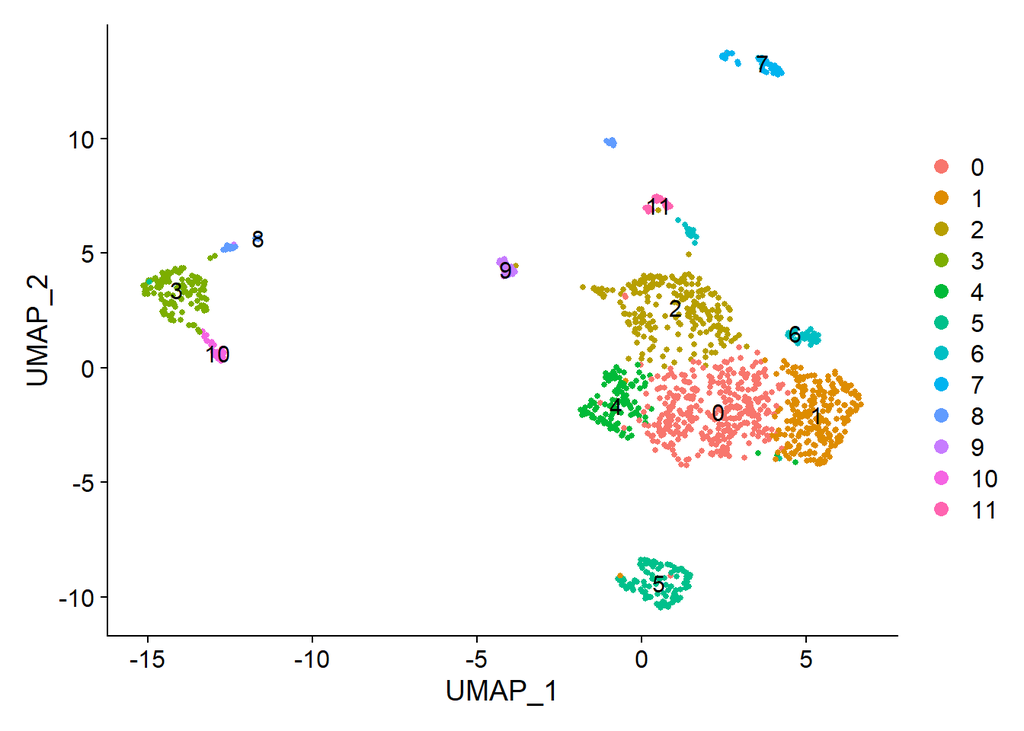

```r
DimPlot(N2234_1_QC, label = TRUE)
```

```r
DefaultAssay(N2234_1_QC) <- "SCT"
```

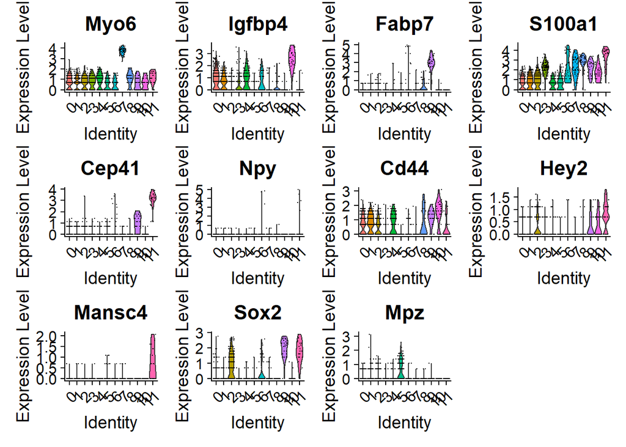

```r
VlnPlot(N2234_1_QC, features = c("Myo6", "Igfbp4", "Fabp7", "S100a1", "Cep41", "Npy", "Cd44", "Hey2", "Mansc4", "Sox2", "Mpz"))
```

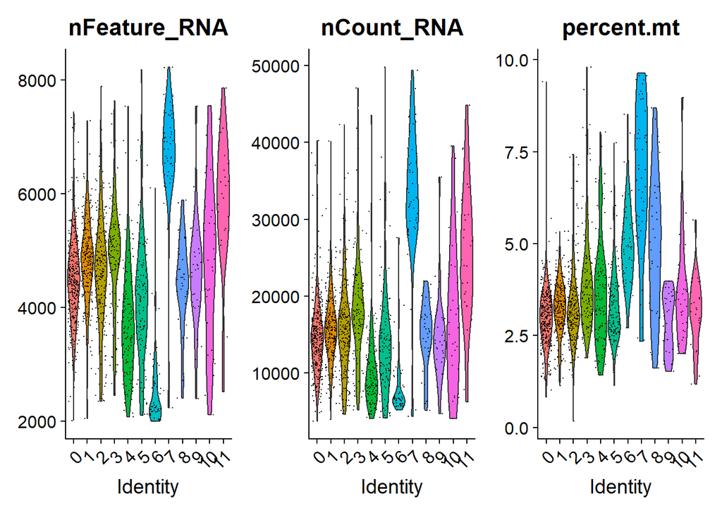

```r
VlnPlot(N2234_1_QC, features = c("nFeature_RNA", "nCount_RNA", "percent.mt"), ncol = 3)
```

Hair cell cluster (cluster7) has high features,

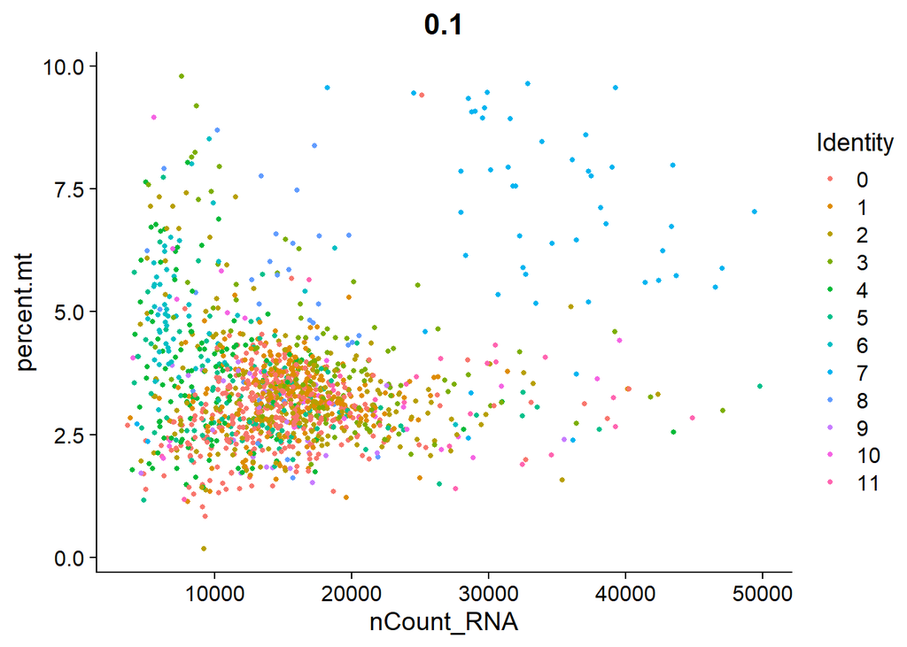

```r
FeatureScatter(N2234_1_QC, feature1 = "nCount_RNA", feature2 = "percent.mt")
```

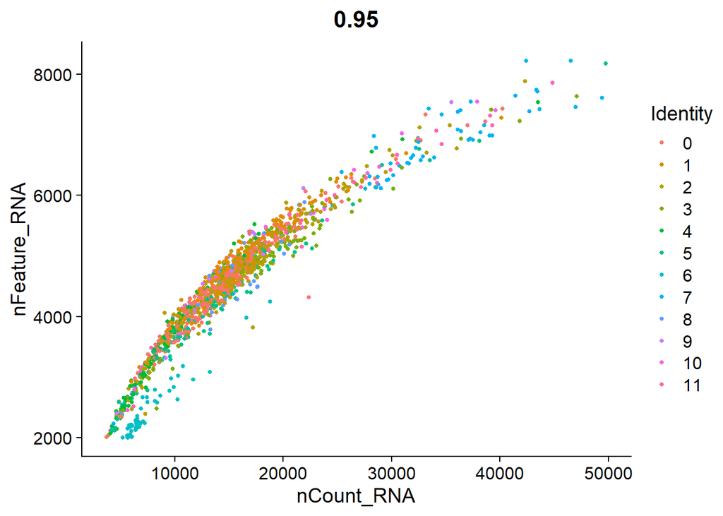

```r
FeatureScatter(N2234_1_QC, feature1 = "nCount_RNA", feature2 = "nFeature_RNA")
```

Cluster 6 separates out quite a bit, but based on the marker gene expression these might be HeC, so I will leave them in.

```r
saveRDS(N2234_1_QC, file = "N2234_1_QC.RDS")
```